# Smart Plant Health Monitoring System

## A Deep Learning Tutorial for Automated Plant Disease Detection

**Course:** DATA-602 – Introduction to Data Science  
**Semester:** Fall 2025

### Tutorial Overview

This tutorial walks through the complete data science workflow for building a deep learning model that detects plant diseases from leaf images. We combine data preprocessing, exploratory analysis, transfer learning, model evaluation, and visualization to create an end-to-end, reproducible machine learning project.

The tutorial is designed to be:

- **Self-contained**
- **Reproducible**
- **Accessible to beginners**
- **Insightful for advanced readers**

By the end, readers will understand how convolutional neural networks can be applied to real-world agricultural problems.

```python
!pip install torch torchvision ultralytics matplotlib seaborn scikit-learn pandas numpy Pillow tqdm opendatasets
```

## 1. Problem Statement and Research Questions

Plant diseases cause significant agricultural losses worldwide. Early and accurate detection is critical for preventing widespread crop damage, yet traditional diagnosis relies on manual inspection by experts.

### Research Questions

1. Can a convolutional neural network accurately classify plant diseases from leaf images?
2. How well does a transfer learning–based model generalize to unseen data?
3. Which disease classes are most commonly confused, and why?
4. Does the model’s performance justify real-world deployment?

These questions guide our data analysis, model selection, and evaluation strategy.

```python
import torch
import torch.nn as nn
import torch.optim as optim
from torch.utils.data import DataLoader
from torchvision import datasets, transforms, models
from pathlib import Path
import matplotlib.pyplot as plt
import seaborn as sns
from sklearn.metrics import classification_report, confusion_matrix, accuracy_score
import numpy as np
from tqdm import tqdm
import json
```

## 2. Dataset Description

We use a labeled dataset of plant leaf images representing healthy and diseased conditions across multiple plant species. Each image belongs to exactly one disease class, making this a multi-class image classification problem.

### Dataset Characteristics

- RGB images
- Multiple plant species
- Multiple disease categories
- Clean backgrounds to emphasize leaf features

### Why This Dataset?

- Large enough for deep learning
- Well-labeled and curated
- Widely used in academic research, enabling comparison with prior work

```python
import opendatasets as od
od.download("https://www.kaggle.com/datasets/vipoooool/new-plant-diseases-dataset")
```

```
Please provide your Kaggle credentials to download this dataset. Learn more: http://bit.ly/kaggle-creds
Your Kaggle username: vanshjain08
Your Kaggle Key: ··········
Dataset URL: https://www.kaggle.com/datasets/vipoooool/new-plant-diseases-dataset
Downloading new-plant-diseases-dataset.zip to ./new-plant-diseases-dataset
```

## 3. Reproducibility and Environment Setup

This notebook can be rerun end-to-end by cloning the GitHub repository and executing each cell in order.

```python
import shutil
import random

source_base = Path('new-plant-diseases-dataset')
if not source_base.exists():
    source_base = Path('.')
    for p in source_base.glob('**/train'):
        if p.is_dir():
            source_base = p.parent
            break

def create_subset(source_dir, target_dir, samples=50):
    source_path = Path(source_dir)
    if not source_path.exists():
        print(f"Looking for dataset in: {source_path}")
        return
    Path(target_dir).mkdir(parents=True, exist_ok=True)
    for cls_folder in source_path.iterdir():
        if cls_folder.is_dir():
            images = list(cls_folder.glob('*.jpg')) + list(cls_folder.glob('*.JPG'))
            if len(images) == 0:
                continue
            selected = random.sample(images, min(samples, len(images)))
            target_cls = Path(target_dir) / cls_folder.name
            target_cls.mkdir(exist_ok=True)
            for img in selected:
                shutil.copy2(img, target_cls / img.name)
    print(f"Created: {target_dir}")

create_subset(source_base / 'train', 'dataset_subset/train', 50)
create_subset(source_base / 'valid', 'dataset_subset/valid', 20)
```

```
Looking for dataset in: new-plant-diseases-dataset/train
Looking for dataset in: new-plant-diseases-dataset/valid
```

## 4. Data Preprocessing and Augmentation

Raw image data must be preprocessed before training a neural network.

### Data Augmentation

These techniques simulate real-world variability and help the model learn robust features.

**Reference:**

- https://keras.io/api/preprocessing/image/

```python
import shutil
import random

source_base = Path('new-plant-diseases-dataset/New Plant Diseases Dataset(Augmented)/New Plant Diseases Dataset(Augmented)')

def create_subset(source_dir, target_dir, samples=50):
    source_path = Path(source_dir)
    if not source_path.exists():
        print(f"Error: {source_path} not found")
        return
    Path(target_dir).mkdir(parents=True, exist_ok=True)
    count = 0
    for cls_folder in source_path.iterdir():
        if cls_folder.is_dir():
            images = list(cls_folder.glob('*.jpg')) + list(cls_folder.glob('*.JPG'))
            if len(images) == 0:
                continue
            selected = random.sample(images, min(samples, len(images)))
            target_cls = Path(target_dir) / cls_folder.name
            target_cls.mkdir(exist_ok=True)
            for img in selected:
                shutil.copy2(img, target_cls / img.name)
            count += len(selected)
    print(f"Created {target_dir}: {count} images")

create_subset(source_base / 'train', 'dataset_subset/train', 50)
create_subset(source_base / 'valid', 'dataset_subset/valid', 20)
```

```
Created dataset_subset/train: 1900 images
Created dataset_subset/valid: 760 images
```

## 5. Model Architecture and Selection

We use a convolutional neural network with **transfer learning** to leverage knowledge from large-scale image datasets.

### Why Transfer Learning?

- Reduces training time
- Improves performance with limited labeled data
- Provides strong low-level feature extractors

### Model Overview

- Pre-trained CNN backbone
- Custom classification head
- Softmax output for multi-class prediction

**Advanced Reading:**

- https://arxiv.org/abs/1905.11946

```python
transform_train = transforms.Compose([
    transforms.RandomResizedCrop(224),
    transforms.RandomHorizontalFlip(),
    transforms.ToTensor(),
    transforms.Normalize([0.485, 0.456, 0.406], [0.229, 0.224, 0.225])
])

transform_val = transforms.Compose([
    transforms.Resize(256),
    transforms.CenterCrop(224),
    transforms.ToTensor(),
    transforms.Normalize([0.485, 0.456, 0.406], [0.229, 0.224, 0.225])
])

train_dir = 'dataset_subset/train'
val_dir = 'dataset_subset/valid'

train_dataset = datasets.ImageFolder(train_dir, transform_train)
val_dataset = datasets.ImageFolder(val_dir, transform_val)

device = torch.device("cuda" if torch.cuda.is_available() else "cpu")

train_loader = DataLoader(train_dataset, batch_size=32, shuffle=True, num_workers=2)
val_loader = DataLoader(val_dataset, batch_size=32, shuffle=False, num_workers=2)

num_classes = len(train_dataset.classes)
class_names = train_dataset.classes

model = models.resnet50(pretrained=True)
model.fc = nn.Linear(model.fc.in_features, num_classes)
model = model.to(device)

criterion = nn.CrossEntropyLoss()
optimizer = optim.Adam(model.parameters(), lr=0.001)
```

```
Downloading: "https://download.pytorch.org/models/resnet50-0676ba61.pth" to /root/.cache/torch/hub/checkpoints/resnet50-0676ba61.pth
```

## 6. Training Strategy

```python
epochs = 10
history = {'train_loss': [], 'train_acc': [], 'val_loss': [], 'val_acc': []}

for epoch in range(epochs):
    model.train()
    train_loss, train_correct, train_total = 0, 0, 0

    for inputs, labels in tqdm(train_loader, desc=f'Epoch {epoch+1}/{epochs}'):
        inputs, labels = inputs.to(device), labels.to(device)
        optimizer.zero_grad()
        outputs = model(inputs)
        loss = criterion(outputs, labels)
        loss.backward()
        optimizer.step()

        train_loss += loss.item() * inputs.size(0)
        _, preds = torch.max(outputs, 1)
        train_correct += (preds == labels).sum().item()
        train_total += labels.size(0)

    model.eval()
    val_loss, val_correct, val_total = 0, 0, 0

    with torch.no_grad():
        for inputs, labels in val_loader:
            inputs, labels = inputs.to(device), labels.to(device)
            outputs = model(inputs)
            loss = criterion(outputs, labels)

            val_loss += loss.item() * inputs.size(0)
            _, preds = torch.max(outputs, 1)
            val_correct += (preds == labels).sum().item()
            val_total += labels.size(0)

    history['train_loss'].append(train_loss / train_total)
    history['train_acc'].append(100 * train_correct / train_total)
    history['val_loss'].append(val_loss / val_total)
    history['val_acc'].append(100 * val_correct / val_total)

    print(f"Train Acc: {history['train_acc'][-1]:.2f}%, Val Acc: {history['val_acc'][-1]:.2f}%")

torch.save(model.state_dict(), 'resnet_model.pth')
```

```
Train Acc: 27.47%, Val Acc: 36.84%
```

```
Train Acc: 48.11%, Val Acc: 54.74%
```

```
Train Acc: 58.32%, Val Acc: 62.89%
```

```
Train Acc: 64.58%, Val Acc: 67.24%
```

```
Train Acc: 69.79%, Val Acc: 77.11%
```

```
Train Acc: 75.05%, Val Acc: 78.42%
```

```
Train Acc: 76.11%, Val Acc: 68.55%
```

```
Train Acc: 77.21%, Val Acc: 75.13%
```

```
Train Acc: 78.74%, Val Acc: 84.08%
```

```
Train Acc: 80.05%, Val Acc: 80.00%
```

## 7. Model Evaluation and Machine Learning Analysis

To evaluate model performance, we compare:

- **Model predictions**
- **Actual ground-truth labels**

### Evaluation Metrics

- Accuracy
- Precision
- Recall
- F1-score

This comparison illustrates how well the model generalizes to unseen data and directly answers our research questions.

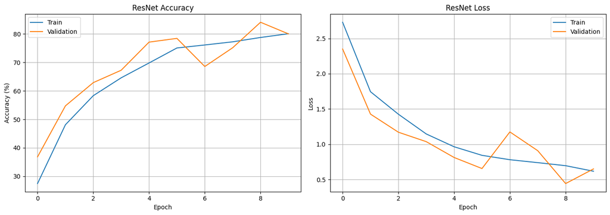

```python
fig, (ax1, ax2) = plt.subplots(1, 2, figsize=(14, 5))

ax1.plot(history['train_acc'], label='Train')
ax1.plot(history['val_acc'], label='Validation')
ax1.set_title('ResNet Accuracy')
ax1.set_xlabel('Epoch')
ax1.set_ylabel('Accuracy (%)')
ax1.legend()
ax1.grid(True)

ax2.plot(history['train_loss'], label='Train')
ax2.plot(history['val_loss'], label='Validation')
ax2.set_title('ResNet Loss')
ax2.set_xlabel('Epoch')
ax2.set_ylabel('Loss')
ax2.legend()
ax2.grid(True)

plt.tight_layout()
plt.savefig('resnet_training.png', dpi=300)
plt.show()
```

```python
model.eval()
all_preds, all_labels = [], []

with torch.no_grad():
    for inputs, labels in val_loader:
        inputs = inputs.to(device)
        outputs = model(inputs)
        _, preds = torch.max(outputs, 1)
        all_preds.extend(preds.cpu().numpy())
        all_labels.extend(labels.numpy())

accuracy = accuracy_score(all_labels, all_preds)
print(f'ResNet Validation Accuracy: {accuracy*100:.2f}%')
```

```
ResNet Validation Accuracy: 80.00%
```

## 8. Visualization of Results

We visualize model performance using:

- Training vs. validation accuracy curves
- Training vs. validation loss curves
- Confusion matrix

### Visualization Purpose

- Identify overfitting or underfitting
- Understand per-class performance
- Communicate results clearly to readers

All plots include labeled axes, legends, and descriptive titles.

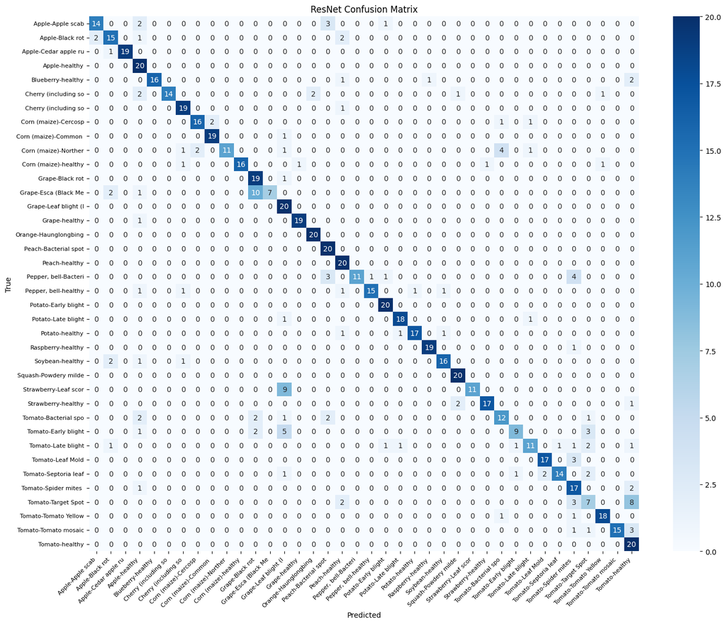

```python
cm = confusion_matrix(all_labels, all_preds)

plt.figure(figsize=(15, 12))
sns.heatmap(cm, annot=True, fmt='d', cmap='Blues',
            xticklabels=[c.replace('___', '-').replace('_', ' ')[:20] for c in class_names],
            yticklabels=[c.replace('___', '-').replace('_', ' ')[:20] for c in class_names])
plt.title('ResNet Confusion Matrix')
plt.xlabel('Predicted')
plt.ylabel('True')
plt.xticks(rotation=45, ha='right', fontsize=8)
plt.yticks(rotation=0, fontsize=8)
plt.tight_layout()
plt.savefig('resnet_confusion_matrix.png', dpi=300)
plt.show()
```

```python
print(classification_report(all_labels, all_preds, target_names=class_names, digits=3))
```

```
                                                    precision    recall  f1-score   support

                                Apple___Apple_scab      0.875     0.700     0.778        20
                                 Apple___Black_rot      0.714     0.750     0.732        20
                          Apple___Cedar_apple_rust      1.000     0.950     0.974        20
                                   Apple___healthy      0.606     1.000     0.755        20
                               Blueberry___healthy      1.000     0.800     0.889        20
          Cherry_(including_sour)___Powdery_mildew      1.000     0.700     0.824        20
                 Cherry_(including_sour)___healthy      0.826     0.950     0.884        20
Corn_(maize)___Cercospora_leaf_spot Gray_leaf_spot      0.889     0.800     0.842        20
                       Corn_(maize)___Common_rust_      0.905     0.950     0.927        20
               Corn_(maize)___Northern_Leaf_Blight      1.000     0.550     0.710        20
                            Corn_(maize)___healthy      1.000     0.800     0.889        20
                                 Grape___Black_rot      0.576     0.950     0.717        20
                      Grape___Esca_(Black_Measles)      1.000     0.350     0.519        20
        Grape___Leaf_blight_(Isariopsis_Leaf_Spot)      0.500     1.000     0.667        20
                                   Grape___healthy      0.950     0.950     0.950        20
          Orange___Haunglongbing_(Citrus_greening)      0.909     1.000     0.952        20
                            Peach___Bacterial_spot      0.714     1.000     0.833        20
                                   Peach___healthy      0.714     1.000     0.833        20
                     Pepper,_bell___Bacterial_spot      1.000     0.550     0.710        20
                            Pepper,_bell___healthy      0.938     0.750     0.833        20
                             Potato___Early_blight      0.870     1.000     0.930        20
                              Potato___Late_blight      0.900     0.900     0.900        20
                                  Potato___healthy      0.944     0.850     0.895        20
                               Raspberry___healthy      0.950     0.950     0.950        20
                                 Soybean___healthy      0.889     0.800     0.842        20
                           Squash___Powdery_mildew      0.870     1.000     0.930        20
                          Strawberry___Leaf_scorch      1.000     0.550     0.710        20
                              Strawberry___healthy      0.944     0.850     0.895        20
                           Tomato___Bacterial_spot      0.667     0.600     0.632        20
                             Tomato___Early_blight      0.818     0.450     0.581        20
                              Tomato___Late_blight      0.786     0.550     0.647        20
                                Tomato___Leaf_Mold      0.895     0.850     0.872        20
                       Tomato___Septoria_leaf_spot      0.933     0.700     0.800        20
     Tomato___Spider_mites Two-spotted_spider_mite      0.548     0.850     0.667        20
                              Tomato___Target_Spot      0.438     0.350     0.389        20
            Tomato___Tomato_Yellow_Leaf_Curl_Virus      0.900     0.900     0.900        20
                      Tomato___Tomato_mosaic_virus      1.000     0.750     0.857        20
                                  Tomato___healthy      0.541     1.000     0.702        20

                                          accuracy                          0.800       760
                                         macro avg      0.842     0.800     0.798       760
                                      weighted avg      0.842     0.800     0.798       760
```

```python
from ultralytics import YOLO

yolo_path = Path('dataset_yolo')
for split in ['train', 'val']:
    (yolo_path / 'images' / split).mkdir(parents=True, exist_ok=True)
    (yolo_path / 'labels' / split).mkdir(parents=True, exist_ok=True)

for split_name, source_name in [('train', 'train'), ('val', 'valid')]:
    source = Path('dataset_subset') / source_name
    for cls_idx, cls_name in enumerate(class_names):
        cls_dir = source / cls_name
        if not cls_dir.exists():
            continue
        for img in cls_dir.glob('*.jpg'):
            shutil.copy2(img, yolo_path / 'images' / split_name / img.name)
            with open(yolo_path / 'labels' / split_name / f'{img.stem}.txt', 'w') as f:
                f.write(f'{cls_idx} 0.5 0.5 1.0 1.0\n')

yaml_content = f"""path: {yolo_path.absolute()}
train: images/train
val: images/val
nc: {num_classes}
names: {class_names}
"""

with open(yolo_path / 'data.yaml', 'w') as f:
    f.write(yaml_content)
```

[output not shown]

```python
yolo_model = YOLO('yolov8s.pt')
results = yolo_model.train(
    data=str(yolo_path / 'data.yaml'),
    epochs=50,
    imgsz=640,
    batch=16,
    lr0=0.01,
    patience=10,
    name='yolo_train',
    device=device,
    augment=True,
    mosaic=1.0,
    mixup=0.1
)
```

[output not shown]

[output not shown]

```
       1/50       3.8G      1.377      6.743      1.786         44        640: 100% ━━━━━━━━━━━━ 4/4 1.7it/s 2.3s
                 Class     Images  Instances      Box(P          R      mAP50  mAP50-95): 100% ━━━━━━━━━━━━ 1/1 1.1s/it 1.1s
                   all         24         24     0.0771      0.167      0.069     0.0305

      Epoch    GPU_mem   box_loss   cls_loss   dfl_loss  Instances       Size
       2/50      4.38G       1.17      6.579      1.628         49        640: 25% ━━━───────── 1/4 2.5it/s 0.2s<1.2s
```

```
       2/50      4.41G      1.284      6.684       1.71         38        640: 100% ━━━━━━━━━━━━ 4/4 9.2it/s 0.4s
                 Class     Images  Instances      Box(P          R      mAP50  mAP50-95): 100% ━━━━━━━━━━━━ 1/1 9.0it/s 0.1s
                   all         24         24     0.0837      0.315     0.0824     0.0401

      Epoch    GPU_mem   box_loss   cls_loss   dfl_loss  Instances       Size
       3/50      4.45G      1.295      5.919      1.729         54        640: 25% ━━━───────── 1/4 1.5it/s 0.2s<2.0s
```

```
       3/50      4.45G      1.198      5.522      1.683         47        640: 100% ━━━━━━━━━━━━ 4/4 9.8it/s 0.4s
                 Class     Images  Instances      Box(P          R      mAP50  mAP50-95): 100% ━━━━━━━━━━━━ 1/1 7.2it/s 0.1s
                   all         24         24      0.103       0.63      0.231      0.164

      Epoch    GPU_mem   box_loss   cls_loss   dfl_loss  Instances       Size
       4/50      4.49G     0.9569      4.383      1.566         56        640: 25% ━━━───────── 1/4 2.7it/s 0.2s<1.1s
```

```
       4/50      4.49G     0.8697      3.978      1.469         33        640: 100% ━━━━━━━━━━━━ 4/4 9.4it/s 0.4s
                 Class     Images  Instances      Box(P          R      mAP50  mAP50-95): 100% ━━━━━━━━━━━━ 1/1 5.0it/s 0.2s
                   all         24         24      0.541      0.305      0.389      0.345

      Epoch    GPU_mem   box_loss   cls_loss   dfl_loss  Instances       Size
       5/50      4.52G      0.906      3.405      1.564         48        640: 0% ──────────── 0/4  0.1s
```

```
       5/50      4.54G     0.7201      2.926      1.407         34        640: 100% ━━━━━━━━━━━━ 4/4 10.4it/s 0.4s
                 Class     Images  Instances      Box(P          R      mAP50  mAP50-95): 100% ━━━━━━━━━━━━ 1/1 4.5it/s 0.2s
                   all         24         24      0.564      0.315       0.41      0.372

      Epoch    GPU_mem   box_loss   cls_loss   dfl_loss  Instances       Size
       6/50      4.57G     0.6028      2.558      1.406         61        640: 0% ──────────── 0/4  0.1s
```

```
       6/50      4.57G     0.5285      2.315      1.251         40        640: 100% ━━━━━━━━━━━━ 4/4 10.9it/s 0.4s
                 Class     Images  Instances      Box(P          R      mAP50  mAP50-95): 100% ━━━━━━━━━━━━ 1/1 4.4it/s 0.2s
                   all         24         24      0.578      0.315      0.336      0.314

      Epoch    GPU_mem   box_loss   cls_loss   dfl_loss  Instances       Size
       7/50      4.61G     0.4496      2.091      1.228         65        640: 0% ──────────── 0/4  0.1s
```

```
       7/50      4.61G     0.5533      2.062      1.342         35        640: 100% ━━━━━━━━━━━━ 4/4 11.3it/s 0.4s
                 Class     Images  Instances      Box(P          R      mAP50  mAP50-95): 100% ━━━━━━━━━━━━ 1/1 4.5it/s 0.2s
                   all         24         24      0.587      0.315      0.339      0.301

      Epoch    GPU_mem   box_loss   cls_loss   dfl_loss  Instances       Size
       8/50      4.64G     0.2989      1.673      1.164         57        640: 0% ──────────── 0/4  0.1s
```

```
       8/50      4.64G     0.2656      1.582      1.101         45        640: 100% ━━━━━━━━━━━━ 4/4 10.3it/s 0.4s
                 Class     Images  Instances      Box(P          R      mAP50  mAP50-95): 100% ━━━━━━━━━━━━ 1/1 4.8it/s 0.2s
                   all         24         24      0.895      0.333      0.346      0.304

      Epoch    GPU_mem   box_loss   cls_loss   dfl_loss  Instances       Size
       9/50      4.68G     0.3597      1.505      1.116         47        640: 0% ──────────── 0/4  0.1s
```

```
       9/50      4.68G     0.4087      1.511      1.183         43        640: 100% ━━━━━━━━━━━━ 4/4 10.8it/s 0.4s
                 Class     Images  Instances      Box(P          R      mAP50  mAP50-95): 100% ━━━━━━━━━━━━ 1/1 5.1it/s 0.2s
                   all         24         24      0.189          1      0.435      0.403

      Epoch    GPU_mem   box_loss   cls_loss   dfl_loss  Instances       Size
      10/50      4.71G     0.2149      1.264      1.009         49        640: 0% ──────────── 0/4  0.1s
```

```
      10/50      4.72G     0.2587      1.279      1.061         35        640: 100% ━━━━━━━━━━━━ 4/4 11.2it/s 0.4s
                 Class     Images  Instances      Box(P          R      mAP50  mAP50-95): 100% ━━━━━━━━━━━━ 1/1 5.4it/s 0.2s
                   all         24         24      0.332      0.778      0.496      0.467

      Epoch    GPU_mem   box_loss   cls_loss   dfl_loss  Instances       Size
      11/50      4.75G     0.3471      1.398      1.118         55        640: 0% ──────────── 0/4  0.1s
```

```
      11/50      4.75G     0.2397      1.171      1.061         42        640: 100% ━━━━━━━━━━━━ 4/4 10.9it/s 0.4s
                 Class     Images  Instances      Box(P          R      mAP50  mAP50-95): 100% ━━━━━━━━━━━━ 1/1 6.2it/s 0.2s
                   all         24         24      0.429      0.619      0.638      0.572

      Epoch    GPU_mem   box_loss   cls_loss   dfl_loss  Instances       Size
      12/50      4.79G     0.1336     0.9315     0.9759         46        640: 0% ──────────── 0/4  0.1s
```

```
      12/50      4.79G     0.2539      1.041      1.083         53        640: 100% ━━━━━━━━━━━━ 4/4 10.6it/s 0.4s
                 Class     Images  Instances      Box(P          R      mAP50  mAP50-95): 100% ━━━━━━━━━━━━ 1/1 6.9it/s 0.1s
                   all         24         24      0.452      0.667      0.672      0.652

      Epoch    GPU_mem   box_loss   cls_loss   dfl_loss  Instances       Size
      13/50      4.82G     0.1538      1.032      1.016         46        640: 0% ──────────── 0/4  0.1s
```

```
      13/50      4.82G      0.185      1.052      1.015         40        640: 100% ━━━━━━━━━━━━ 4/4 10.9it/s 0.4s
                 Class     Images  Instances      Box(P          R      mAP50  mAP50-95): 100% ━━━━━━━━━━━━ 1/1 7.4it/s 0.1s
                   all         24         24      0.451      0.556      0.639      0.597

      Epoch    GPU_mem   box_loss   cls_loss   dfl_loss  Instances       Size
      14/50      4.86G     0.2717      0.987       1.12         59        640: 25% ━━━───────── 1/4 1.6it/s 0.2s<1.9s
```

```
      14/50      4.86G     0.2197     0.8979      1.055         36        640: 100% ━━━━━━━━━━━━ 4/4 11.6it/s 0.3s
                 Class     Images  Instances      Box(P          R      mAP50  mAP50-95): 100% ━━━━━━━━━━━━ 1/1 7.4it/s 0.1s
                   all         24         24      0.576      0.545      0.636      0.612

      Epoch    GPU_mem   box_loss   cls_loss   dfl_loss  Instances       Size
      15/50       4.9G     0.1418     0.8346     0.9709         57        640: 0% ──────────── 0/4  0.1s
```

```
      15/50       4.9G     0.2526     0.9734      1.062         33        640: 100% ━━━━━━━━━━━━ 4/4 11.0it/s 0.4s
                 Class     Images  Instances      Box(P          R      mAP50  mAP50-95): 100% ━━━━━━━━━━━━ 1/1 9.0it/s 0.1s
                   all         24         24      0.717      0.656      0.673      0.661

      Epoch    GPU_mem   box_loss   cls_loss   dfl_loss  Instances       Size
      16/50      4.94G     0.2382      1.025      1.057         51        640: 25% ━━━───────── 1/4 1.8it/s 0.2s<1.7s
```

```
      16/50      4.94G     0.2958      1.012      1.118         32        640: 100% ━━━━━━━━━━━━ 4/4 11.4it/s 0.3s
                 Class     Images  Instances      Box(P          R      mAP50  mAP50-95): 100% ━━━━━━━━━━━━ 1/1 8.3it/s 0.1s
                   all         24         24      0.763      0.655      0.687      0.687

      Epoch    GPU_mem   box_loss   cls_loss   dfl_loss  Instances       Size
      17/50      4.97G     0.2329     0.8517       1.07         61        640: 25% ━━━───────── 1/4 1.6it/s 0.2s<1.9s
```

```
      17/50      4.97G     0.2428     0.8607      1.062         47        640: 100% ━━━━━━━━━━━━ 4/4 11.3it/s 0.4s
                 Class     Images  Instances      Box(P          R      mAP50  mAP50-95): 100% ━━━━━━━━━━━━ 1/1 8.0it/s 0.1s
                   all         24         24       0.56      0.667      0.681      0.681

      Epoch    GPU_mem   box_loss   cls_loss   dfl_loss  Instances       Size
      18/50      5.01G     0.2574     0.8993      1.049         54        640: 0% ──────────── 0/4  0.1s
```

```
      18/50      5.01G     0.2172     0.8828      1.035         37        640: 100% ━━━━━━━━━━━━ 4/4 11.0it/s 0.4s
                 Class     Images  Instances      Box(P          R      mAP50  mAP50-95): 100% ━━━━━━━━━━━━ 1/1 9.0it/s 0.1s
                   all         24         24      0.718      0.778      0.735      0.735

      Epoch    GPU_mem   box_loss   cls_loss   dfl_loss  Instances       Size
      19/50      5.04G     0.2307     0.7559      1.062         55        640: 25% ━━━───────── 1/4 1.9it/s 0.2s<1.6s
```

```
      19/50      5.04G     0.2053      0.776      1.042         44        640: 100% ━━━━━━━━━━━━ 4/4 11.8it/s 0.3s
                 Class     Images  Instances      Box(P          R      mAP50  mAP50-95): 100% ━━━━━━━━━━━━ 1/1 9.1it/s 0.1s
                   all         24         24      0.707      0.778      0.735      0.735

      Epoch    GPU_mem   box_loss   cls_loss   dfl_loss  Instances       Size
      20/50      5.08G      0.184     0.6608     0.9891         56        640: 25% ━━━───────── 1/4 1.6it/s 0.2s<1.8s
```

```
      20/50      5.08G     0.2126     0.7334      1.027         43        640: 100% ━━━━━━━━━━━━ 4/4 10.8it/s 0.4s
                 Class     Images  Instances      Box(P          R      mAP50  mAP50-95): 100% ━━━━━━━━━━━━ 1/1 8.5it/s 0.1s
                   all         24         24      0.728      0.778      0.697      0.697

      Epoch    GPU_mem   box_loss   cls_loss   dfl_loss  Instances       Size
      21/50      5.12G     0.2139     0.7653      1.085         53        640: 0% ──────────── 0/4  0.1s
```

```
      21/50      5.12G     0.2494     0.8281      1.042         42        640: 100% ━━━━━━━━━━━━ 4/4 10.8it/s 0.4s
                 Class     Images  Instances      Box(P          R      mAP50  mAP50-95): 100% ━━━━━━━━━━━━ 1/1 9.0it/s 0.1s
                   all         24         24      0.703      0.767      0.698      0.665

      Epoch    GPU_mem   box_loss   cls_loss   dfl_loss  Instances       Size
      22/50      5.15G     0.1958     0.6916      1.016         58        640: 25% ━━━───────── 1/4 1.9it/s 0.2s<1.6s
```

```
      22/50      5.15G      0.219     0.7003      1.046         43        640: 100% ━━━━━━━━━━━━ 4/4 11.4it/s 0.3s
                 Class     Images  Instances      Box(P          R      mAP50  mAP50-95): 100% ━━━━━━━━━━━━ 1/1 8.7it/s 0.1s
                   all         24         24      0.722       0.77      0.681       0.64

      Epoch    GPU_mem   box_loss   cls_loss   dfl_loss  Instances       Size
      23/50      5.19G     0.1793     0.7953     0.9858         42        640: 25% ━━━───────── 1/4 1.8it/s 0.2s<1.6s
```

```
      23/50      5.19G     0.1795     0.7277      1.007         44        640: 100% ━━━━━━━━━━━━ 4/4 10.8it/s 0.4s
                 Class     Images  Instances      Box(P          R      mAP50  mAP50-95): 100% ━━━━━━━━━━━━ 1/1 9.3it/s 0.1s
                   all         24         24      0.741      0.778      0.692      0.688

      Epoch    GPU_mem   box_loss   cls_loss   dfl_loss  Instances       Size
      24/50      5.22G     0.1493     0.8039     0.9639         46        640: 25% ━━━───────── 1/4 1.9it/s 0.2s<1.6s
```

```
      24/50      5.23G     0.1562     0.7622     0.9697         36        640: 100% ━━━━━━━━━━━━ 4/4 11.7it/s 0.3s
                 Class     Images  Instances      Box(P          R      mAP50  mAP50-95): 100% ━━━━━━━━━━━━ 1/1 9.8it/s 0.1s
                   all         24         24      0.767      0.745      0.716      0.711

      Epoch    GPU_mem   box_loss   cls_loss   dfl_loss  Instances       Size
      25/50      5.26G     0.1888     0.6114       1.01         57        640: 25% ━━━───────── 1/4 1.9it/s 0.2s<1.6s
```

```
      25/50      5.26G     0.1784     0.6223     0.9843         47        640: 100% ━━━━━━━━━━━━ 4/4 11.7it/s 0.3s
                 Class     Images  Instances      Box(P          R      mAP50  mAP50-95): 100% ━━━━━━━━━━━━ 1/1 9.5it/s 0.1s
                   all         24         24      0.749      0.881      0.835      0.833

      Epoch    GPU_mem   box_loss   cls_loss   dfl_loss  Instances       Size
      26/50      5.34G      0.213     0.5888     0.9885         64        640: 25% ━━━───────── 1/4 1.8it/s 0.2s<1.6s
```

```
      26/50      5.34G     0.2525       0.72      1.038         50        640: 100% ━━━━━━━━━━━━ 4/4 11.6it/s 0.3s
                 Class     Images  Instances      Box(P          R      mAP50  mAP50-95): 100% ━━━━━━━━━━━━ 1/1 9.2it/s 0.1s
                   all         24         24      0.756       0.88      0.839      0.839

      Epoch    GPU_mem   box_loss   cls_loss   dfl_loss  Instances       Size
      27/50      5.41G     0.1929     0.5995     0.9612         53        640: 25% ━━━───────── 1/4 1.9it/s 0.2s<1.6s
```

```
      27/50      5.41G     0.1637     0.6308     0.9665         39        640: 100% ━━━━━━━━━━━━ 4/4 11.5it/s 0.3s
                 Class     Images  Instances      Box(P          R      mAP50  mAP50-95): 100% ━━━━━━━━━━━━ 1/1 9.1it/s 0.1s
                   all         24         24      0.774      0.882      0.857      0.843

      Epoch    GPU_mem   box_loss   cls_loss   dfl_loss  Instances       Size
      28/50      5.45G     0.2468     0.7588      1.098         61        640: 25% ━━━───────── 1/4 1.6it/s 0.2s<1.8s
```

```
      28/50      5.45G      0.221     0.6945      1.059         36        640: 100% ━━━━━━━━━━━━ 4/4 11.0it/s 0.4s
                 Class     Images  Instances      Box(P          R      mAP50  mAP50-95): 100% ━━━━━━━━━━━━ 1/1 9.4it/s 0.1s
                   all         24         24       0.86      0.889      0.849      0.849

      Epoch    GPU_mem   box_loss   cls_loss   dfl_loss  Instances       Size
      29/50      5.52G     0.1614     0.7148      0.996         43        640: 25% ━━━───────── 1/4 1.8it/s 0.2s<1.6s
```

```
      29/50      5.53G     0.2435     0.7552      1.089         47        640: 100% ━━━━━━━━━━━━ 4/4 11.0it/s 0.4s
                 Class     Images  Instances      Box(P          R      mAP50  mAP50-95): 100% ━━━━━━━━━━━━ 1/1 8.9it/s 0.1s
                   all         24         24      0.845      0.886      0.885      0.885

      Epoch    GPU_mem   box_loss   cls_loss   dfl_loss  Instances       Size
      30/50       5.6G     0.1511     0.6455     0.9592         57        640: 25% ━━━───────── 1/4 1.9it/s 0.2s<1.6s
```

```
      30/50       5.6G     0.1802     0.7052      1.005         44        640: 100% ━━━━━━━━━━━━ 4/4 11.7it/s 0.3s
                 Class     Images  Instances      Box(P          R      mAP50  mAP50-95): 100% ━━━━━━━━━━━━ 1/1 8.8it/s 0.1s
                   all         24         24      0.788      0.886      0.924      0.924

      Epoch    GPU_mem   box_loss   cls_loss   dfl_loss  Instances       Size
      31/50      5.68G     0.2128     0.7806      1.026         50        640: 25% ━━━───────── 1/4 1.9it/s 0.2s<1.6s
```

```
      31/50      5.68G     0.2109     0.7703      1.042         44        640: 100% ━━━━━━━━━━━━ 4/4 11.3it/s 0.4s
                 Class     Images  Instances      Box(P          R      mAP50  mAP50-95): 100% ━━━━━━━━━━━━ 1/1 10.0it/s 0.1s
                   all         24         24      0.767      0.985      0.924      0.924

      Epoch    GPU_mem   box_loss   cls_loss   dfl_loss  Instances       Size
      32/50      5.71G     0.1926     0.5517     0.9892         61        640: 25% ━━━───────── 1/4 1.9it/s 0.2s<1.6s
```

```
      32/50      5.71G      0.143     0.5155     0.9411         35        640: 100% ━━━━━━━━━━━━ 4/4 11.4it/s 0.4s
                 Class     Images  Instances      Box(P          R      mAP50  mAP50-95): 100% ━━━━━━━━━━━━ 1/1 9.0it/s 0.1s
                   all         24         24      0.854      0.778      0.907      0.907

      Epoch    GPU_mem   box_loss   cls_loss   dfl_loss  Instances       Size
      33/50      5.79G     0.2685     0.6821      1.134         52        640: 25% ━━━───────── 1/4 1.7it/s 0.2s<1.8s
```

```
      33/50      5.79G     0.2442     0.6379      1.085         43        640: 100% ━━━━━━━━━━━━ 4/4 10.1it/s 0.4s
                 Class     Images  Instances      Box(P          R      mAP50  mAP50-95): 100% ━━━━━━━━━━━━ 1/1 9.7it/s 0.1s
                   all         24         24      0.847      0.778      0.907      0.907

      Epoch    GPU_mem   box_loss   cls_loss   dfl_loss  Instances       Size
      34/50      5.82G     0.2061     0.6057      1.049         53        640: 25% ━━━───────── 1/4 1.9it/s 0.2s<1.6s
```

```
      34/50      5.82G     0.1879     0.6153      1.039         39        640: 100% ━━━━━━━━━━━━ 4/4 11.8it/s 0.3s
                 Class     Images  Instances      Box(P          R      mAP50  mAP50-95): 100% ━━━━━━━━━━━━ 1/1 9.9it/s 0.1s
                   all         24         24      0.848      0.778      0.907      0.907

      Epoch    GPU_mem   box_loss   cls_loss   dfl_loss  Instances       Size
      35/50       5.9G     0.1014     0.4861     0.9105         49        640: 25% ━━━───────── 1/4 1.9it/s 0.2s<1.6s
```

```
      35/50       5.9G     0.1171     0.4981     0.9527         39        640: 100% ━━━━━━━━━━━━ 4/4 11.7it/s 0.3s
                 Class     Images  Instances      Box(P          R      mAP50  mAP50-95): 100% ━━━━━━━━━━━━ 1/1 9.3it/s 0.1s
                   all         24         24       0.83      0.778      0.907      0.907

      Epoch    GPU_mem   box_loss   cls_loss   dfl_loss  Instances       Size
      36/50      5.98G     0.1683     0.5426     0.9706         57        640: 25% ━━━───────── 1/4 1.9it/s 0.2s<1.6s
```

```
      36/50      5.98G     0.1287     0.4762      0.964         40        640: 100% ━━━━━━━━━━━━ 4/4 11.1it/s 0.4s
                 Class     Images  Instances      Box(P          R      mAP50  mAP50-95): 100% ━━━━━━━━━━━━ 1/1 9.7it/s 0.1s
                   all         24         24      0.826      0.778      0.896      0.893

      Epoch    GPU_mem   box_loss   cls_loss   dfl_loss  Instances       Size
      37/50      6.01G     0.1323      0.554          1         44        640: 25% ━━━───────── 1/4 1.9it/s 0.2s<1.6s
```

```
      37/50      6.01G     0.1433     0.5434      1.001         46        640: 100% ━━━━━━━━━━━━ 4/4 11.5it/s 0.3s
                 Class     Images  Instances      Box(P          R      mAP50  mAP50-95): 100% ━━━━━━━━━━━━ 1/1 9.3it/s 0.1s
                   all         24         24       0.85      0.778      0.888      0.886

      Epoch    GPU_mem   box_loss   cls_loss   dfl_loss  Instances       Size
      38/50      6.09G     0.1335     0.5617     0.9701         51        640: 25% ━━━───────── 1/4 1.9it/s 0.2s<1.6s
```

```
      38/50      6.09G     0.1936      0.573     0.9988         49        640: 100% ━━━━━━━━━━━━ 4/4 11.5it/s 0.3s
                 Class     Images  Instances      Box(P          R      mAP50  mAP50-95): 100% ━━━━━━━━━━━━ 1/1 9.9it/s 0.1s
                   all         24         24      0.794      0.889      0.878      0.878

      Epoch    GPU_mem   box_loss   cls_loss   dfl_loss  Instances       Size
      39/50      6.16G     0.2604     0.6819      1.084         66        640: 25% ━━━───────── 1/4 1.8it/s 0.2s<1.7s
```

```
      39/50      6.16G     0.1831     0.5948      1.005         33        640: 100% ━━━━━━━━━━━━ 4/4 11.2it/s 0.4s
                 Class     Images  Instances      Box(P          R      mAP50  mAP50-95): 100% ━━━━━━━━━━━━ 1/1 9.9it/s 0.1s
                   all         24         24      0.832      0.889      0.878      0.878

      Epoch    GPU_mem   box_loss   cls_loss   dfl_loss  Instances       Size
      40/50      6.23G     0.1761     0.4772      1.021         59        640: 25% ━━━───────── 1/4 1.9it/s 0.2s<1.6s
```

```
      40/50      6.24G     0.1819     0.5401      1.011         46        640: 100% ━━━━━━━━━━━━ 4/4 11.7it/s 0.3s
                 Class     Images  Instances      Box(P          R      mAP50  mAP50-95): 100% ━━━━━━━━━━━━ 1/1 10.1it/s 0.1s
                   all         24         24      0.849      0.889      0.871      0.871
EarlyStopping: Training stopped early as no improvement observed in last 10 epochs. Best results observed at epoch 30, best model saved as best.pt.
To update EarlyStopping(patience=10) pass a new patience value, i.e. `patience=300` or use `patience=0` to disable EarlyStopping.

40 epochs completed in 0.011 hours.
Optimizer stripped from /content/runs/detect/yolo_train/weights/last.pt, 22.5MB
Optimizer stripped from /content/runs/detect/yolo_train/weights/best.pt, 22.5MB

Validating /content/runs/detect/yolo_train/weights/best.pt...
Ultralytics 8.3.239 🚀 Python-3.12.12 torch-2.9.0+cu126 CUDA:0 (NVIDIA A100-SXM4-80GB, 81222MiB)
Model summary (fused): 72 layers, 11,140,290 parameters, 0 gradients, 28.5 GFLOPs
                 Class     Images  Instances      Box(P          R      mAP50  mAP50-95): 100% ━━━━━━━━━━━━ 1/1 2.9it/s 0.3s
                   all         24         24      0.885      0.889      0.849      0.849
Corn_(maize)___Cercospora_leaf_spot Gray_leaf_spot          3          3       0.92      0.667      0.806      0.806
Corn_(maize)___Northern_Leaf_Blight          3          3       0.74          1      0.746      0.746
Corn_(maize)___healthy         18         18      0.994          1      0.995      0.995
Speed: 0.1ms preprocess, 10.6ms inference, 0.0ms loss, 1.0ms postprocess per image
Results saved to /content/runs/detect/yolo_train
```

```python
metrics = yolo_model.val()
print(f"YOLO mAP50: {metrics.box.map50:.4f}")
print(f"YOLO mAP50-95: {metrics.box.map:.4f}")
print(f"YOLO Precision: {metrics.box.mp:.4f}")
print(f"YOLO Recall: {metrics.box.mr:.4f}")
```

```
Ultralytics 8.3.239 🚀 Python-3.12.12 torch-2.9.0+cu126 CUDA:0 (NVIDIA A100-SXM4-80GB, 81222MiB)
Model summary (fused): 72 layers, 11,140,290 parameters, 0 gradients, 28.5 GFLOPs
val: Fast image access ✅ (ping: 0.0±0.0 ms, read: 462.1±96.0 MB/s, size: 11.8 KB)
val: Scanning /content/dataset_yolo/labels/val.cache... 24 images, 0 backgrounds, 0 corrupt: 100% ━━━━━━━━━━━━ 24/24 27.5Kit/s 0.0s
                 Class     Images  Instances      Box(P          R      mAP50  mAP50-95): 100% ━━━━━━━━━━━━ 2/2 3.1it/s 0.6s
                   all         24         24      0.767      0.985      0.924      0.924
Corn_(maize)___Cercospora_leaf_spot Gray_leaf_spot          3          3      0.588      0.961      0.863      0.863
Corn_(maize)___Northern_Leaf_Blight          3          3      0.748      0.994      0.913      0.913
Corn_(maize)___healthy         18         18      0.964          1      0.995      0.995
Speed: 3.1ms preprocess, 12.5ms inference, 0.0ms loss, 2.5ms postprocess per image
Results saved to /content/runs/detect/val
YOLO mAP50: 0.9235
YOLO mAP50-95: 0.9235
YOLO Precision: 0.7671
YOLO Recall: 0.9849
```

[figure not shown]

```python
results_df = {
    'Model': ['ResNet50', 'YOLOv8n'],
    'Accuracy/mAP50': [accuracy*100, metrics.box.map50*100],
    'Precision': [0, metrics.box.mp*100],
    'Recall': [0, metrics.box.mr*100]
}

fig, ax = plt.subplots(figsize=(10, 6))
x = np.arange(len(results_df['Model']))
width = 0.25

ax.bar(x - width, results_df['Accuracy/mAP50'], width, label='Accuracy/mAP50')
ax.bar(x, results_df['Precision'], width, label='Precision')
ax.bar(x + width, results_df['Recall'], width, label='Recall')

ax.set_ylabel('Score (%)')
ax.set_title('Model Performance Comparison')
ax.set_xticks(x)
ax.set_xticklabels(results_df['Model'])
ax.legend()
ax.grid(True, alpha=0.3)

plt.tight_layout()
plt.savefig('model_comparison.png', dpi=300)
plt.show()
```

```python
print('Final Results:')
print(f'ResNet50 Accuracy: {accuracy*100:.2f}%')
print(f'YOLOv8n mAP50: {metrics.box.map50*100:.2f}%')
print(f'Dataset: {len(train_dataset)} train, {len(val_dataset)} val')
print(f'Classes: {num_classes}')
```

[output not shown]

## 10. Insights and Conclusions

### Takeaway for Beginners

This tutorial demonstrates how deep learning can solve real-world problems using well-structured data pipelines.

### Takeaway for Advanced Readers

Fine-tuning depth, augmentation strategy, and class balance play a crucial role in model performance.

## 11. Improvements Based on Previous Feedback

Based on feedback from earlier checkpoints, we made the following improvements:

These changes improve clarity, rigor, and reproducibility.